# R tutorial for Lab – 4

Somak Dutta

**First load the required libraries (will require ggplot2 for plotting and emmeans for anova table and testing contrasts)**

**NOTE**: `emmeans` may not be installed in your system. Install it (one time deal) by calling from Rstudi console: `install.packages("emmeans")`

```r
library(ggplot2)
library(emmeans)
```

Read the data:

```r
donut = read.table("Doughnuts.dat",header = T)
str(donut)
```

```
## 'data.frame':    24 obs. of  2 variables:
##  $ Absorbed: int  65 73 69 78 57 96 78 91 97 82 ...
##  $ OilType : Factor w/ 4 levels "CornOil","HyCornOil",..: 1 1 1 1 1 1 2 2 2 2 ...
```

Obtain the group means:

```r
aggregate(Absorbed ~ OilType,data=donut,FUN = mean)
```

```
##     OilType Absorbed
## 1   CornOil       73
## 2 HyCornOil       85
## 3  HySoyOil       76
## 4    SoyOil       62
```

Obtain the group s.d.’s:

```r
aggregate(Absorbed ~ OilType,data=donut,FUN = sd)
```

```
##     OilType Absorbed
## 1   CornOil 13.34166
## 2 HyCornOil  7.77174
## 3  HySoyOil  9.87927
## 4    SoyOil  8.22192
```

Draw side-by-side boxplots:

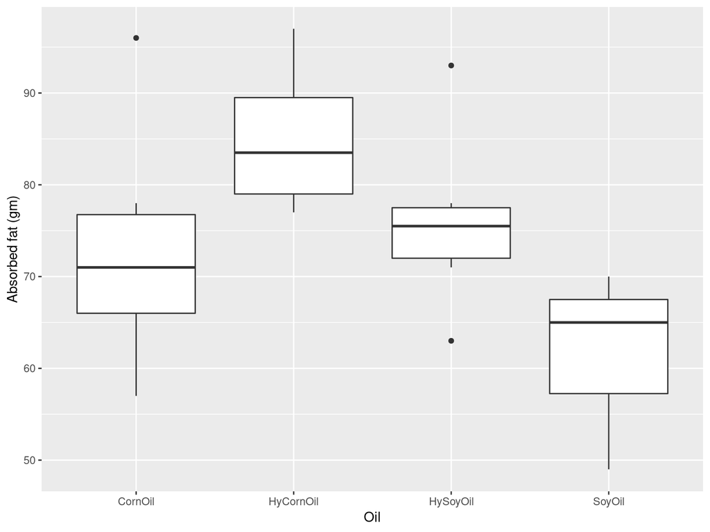

```r
ggplot(donut,aes(x=OilType,y=Absorbed)) + geom_boxplot() + xlab("Oil") + ylab("Absorbed fat (gm)")
```

Obtain the ANOVA table: It’s done in two stages. First we use `lm` to fit the model and then use `anova` to obtain the anova table. The syntax of `lm` is quite similar to the `t.test` you’ve been using: on the left of the formula (e.g. `Absorbed ~ OilType`) goes the response and the right goes the factor for groups.

```r
fit = lm(Absorbed ~ OilType,data=donut)
anova(fit)
```

```
## Analysis of Variance Table
##
## Response: Absorbed
##           Df Sum Sq Mean Sq F value  Pr(>F)
## OilType    3   1620   540.0   5.352 0.00718 **
## Residuals 20   2018   100.9
## ---
## Signif. codes:  0 '***' 0.001 '**' 0.01 '*' 0.05 '.' 0.1 ' ' 1
```

To test variious contrasts involving the oils, first compute the marginal means and their s.d’s:

```r
oil.emm = emmeans(fit,~OilType)
oil.emm
```

```
##  OilType   emmean  SE df lower.CL upper.CL
##  CornOil       73 4.1 20     64.4     81.6
##  HyCornOil     85 4.1 20     76.4     93.6
##  HySoyOil      76 4.1 20     67.4     84.6
##  SoyOil        62 4.1 20     53.4     70.6
##
## Confidence level used: 0.95
```

The table above gives the marginal means (i.e. group means) of the four groups and their s.e.’s. Note that because the design is balanced (i.e. same sample size in each group), the s.e.’s are all equal.

Now let’s test the first contrast: “Test for a difference between regular corn oil and hydrogenated corn oil.” As discussed in the lecture, the contrast coefficients are 1,-1,0 and 0. We use the `contrast` function from `emmeans` as follows. The syntax is slightly complicated, but with practice you’ll become an expert.

Note that the function `c()` creates a vector with the input numbers. For example, `c(1,-1,0,0)` is the vector `[1 -1 0 0]`.

```r
contrast(oil.emm,list("Regular - hyd. corn oil"=c(1,-1,0,0)))
```

```
##  contrast                estimate  SE df t.ratio p.value
##  Regular - hyd. corn oil      -12 5.8 20 -2.069  0.0517
```

Now test the other contrasts (we can use multiple contrasts in one contrast statement).

Note in the below:`0.5*c(-1,1,1,-1))` is same as `c(-0.5, 0.5, 0.5, -0.5)`. Sometimes is easier to write in the former form because typing whole number is less stressful on the finger :P

```r
contrast(oil.emm, list( "problem4"=c(0,0,-1,1),
                        "problem5"=c(0.5,0.5,-0.5,-0.5),
                        "problem6"=0.5*c(-1,1,1,-1)))
```

```
##  contrast estimate  SE df t.ratio p.value
##  problem4      -14 5.8 20 -2.414  0.0255
##  problem5       10 4.1 20  2.439  0.0242
##  problem6       13 4.1 20  3.170  0.0048
```